# Aids Data Set

We decided to answer Question 2: HOW MUCH DO THEY DONATE? How much do countries donate and receive? Who donates the most/least? Are there countries that donate and also receive? How does the amount donated/received by country change over time?

This next table displays the amount donated by country.

```
## # A tibble: 10 x 2
##    donor          total_donation
##    <chr>                   <dbl>
##  1 Australia          2446616312
##  2 Austria             784068952
##  3 Belgium            2144445270
##  4 Brazil                1134440
##  5 Canada             7466338200
##  6 Chile                  564349
##  7 Colombia               190795
##  8 Cyprus                   5599
##  9 Czech Republic        8930435
## 10 Denmark            2952416405
```

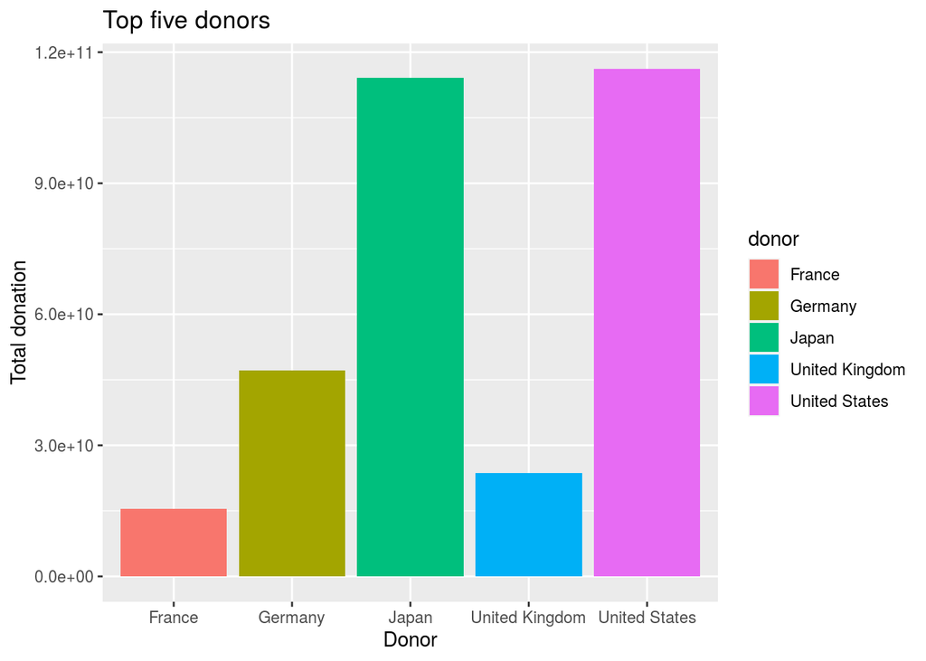

Here are the bottom five donors.

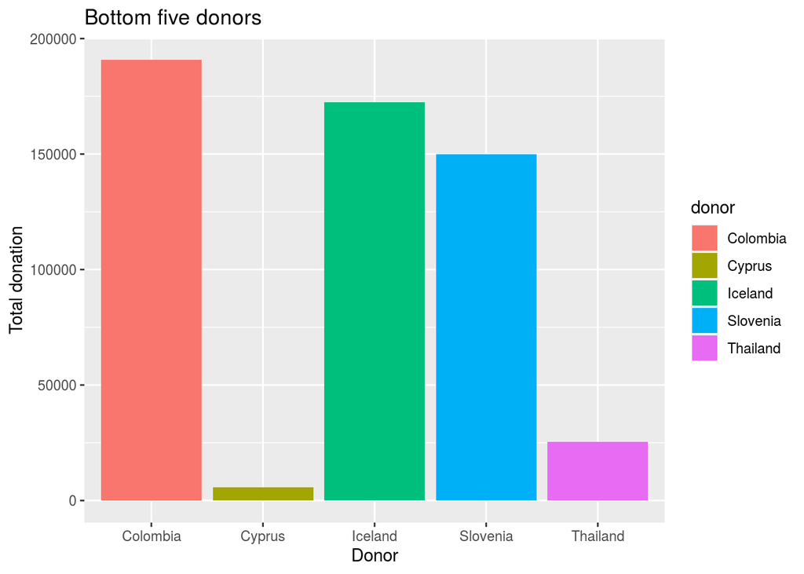

Similarly, this table displays the amount received by country.

```
## # A tibble: 10 x 2
##    recipient      total_receipt
##    <chr>                  <dbl>
##  1 Australia         2572618261
##  2 Austria            770267419
##  3 Belgium            184346233
##  4 Brazil           36607258078
##  5 Canada            4068652966
##  6 Chile             7334129130
##  7 Colombia         25530536307
##  8 Cyprus             968154947
##  9 Czech Republic    2141913341
## 10 Denmark            166310586
```

Five top recipients.

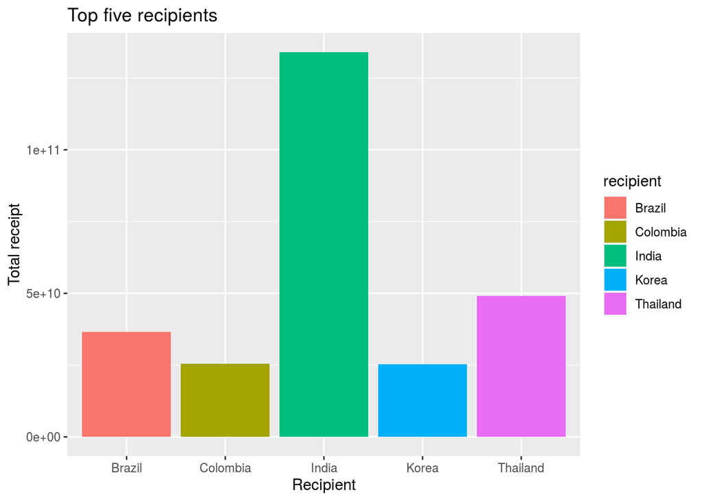

Five bottom recipients.

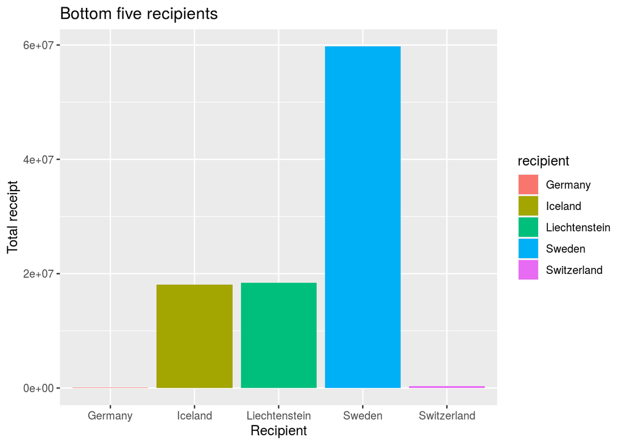

These above tables answer Question 1 and 2.

Question 3: which countries both receive and donate? For Question 3, we made two dataframes, one containing distinct donors and another with distinct recipients. We used inner join on the donors and recipients tables to solve this problem.

```
##          donor
## 1 Saudi Arabia
## 2       Kuwait
## 3        Qatar
## 4       Brazil
## 5     Colombia
```

To address the last question, we first considered just Australia and tracked the amount donated and received over time.

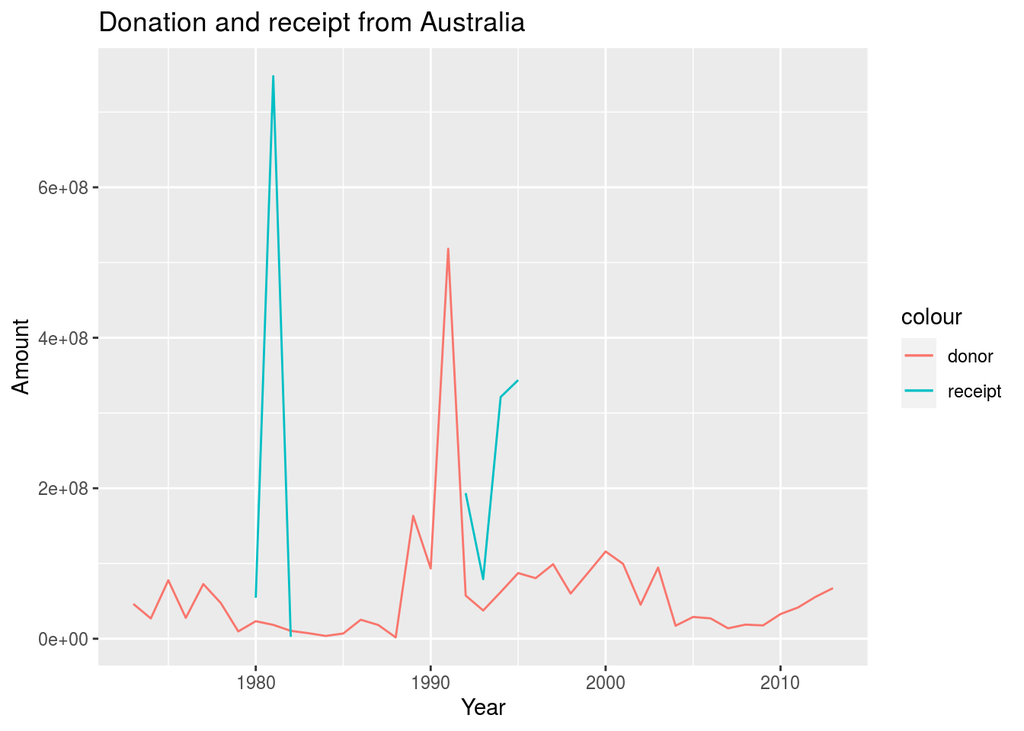

However, we decided that it would be best to look at total donations for all countries over time.

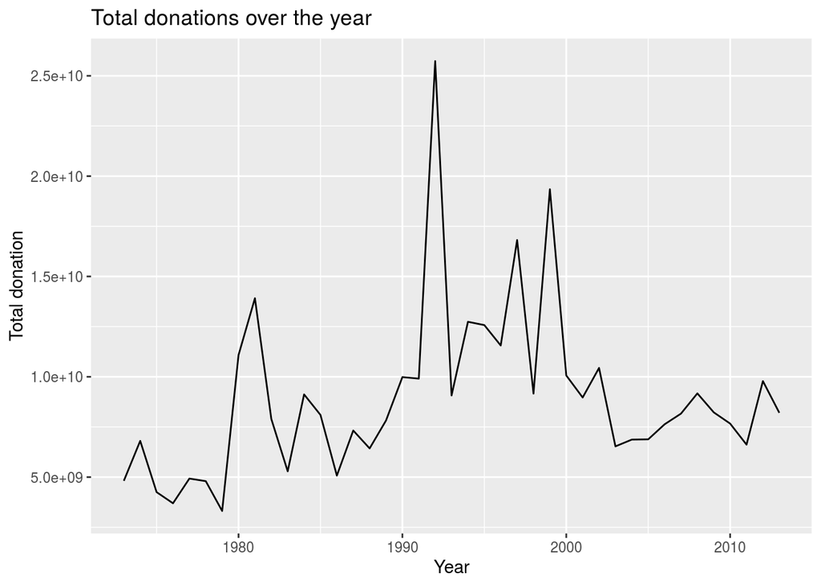

Alternatively…

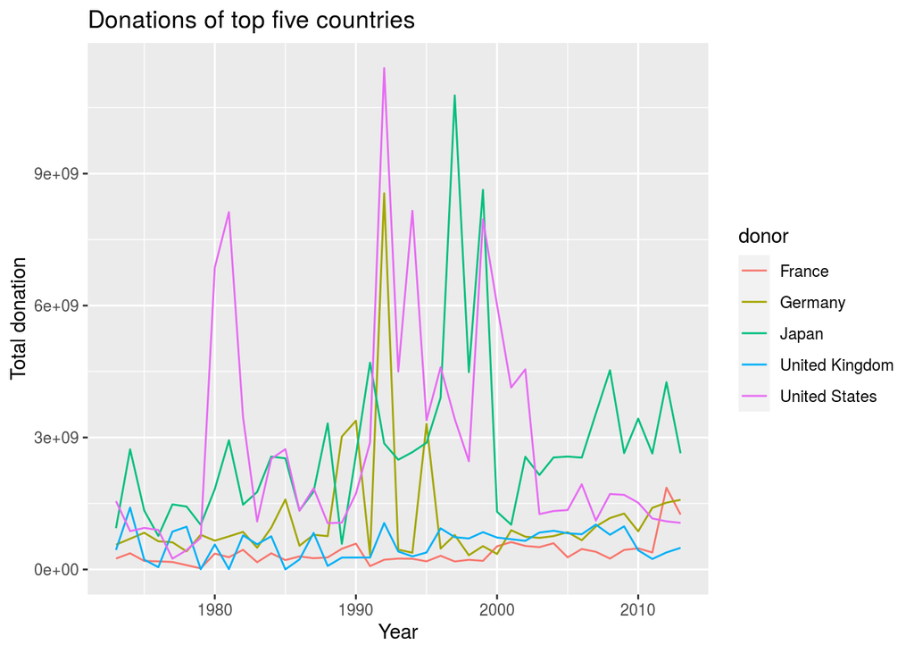

Why is there an increase around 1991? Maybe fewer countries donated?

```
##             donor
## 1   United States
## 2           Italy
## 3          France
## 4     Switzerland
## 5           Japan
## 6     Netherlands
## 7         Germany
## 8          Sweden
## 9           Spain
## 10        Denmark
## 11 United Kingdom
## 12        Austria
## 13      Australia
## 14        Finland
## 15         Norway
## 16         Canada
```